# Allstate_Claims_Severity

In P&C insurance company, actuaries usually use techniques like [Claims reserving with R](https://cran.r-project.org/web/packages/ChainLadder/vignettes/ChainLadder.pdf) to estimate claim liabilities. These datasets, unfortunately, didn't organize in the usual format, by calender year or by accident year. So in this notebook, we will use machine learning algorithm to make predictions.

```python
# supress unnecessary warnings so the notebook looks clean
import warnings
warnings.filterwarnings('ignore')

import time
from math import exp, log

# import libraries to quickly analyze data
import numpy as np
import pandas as pd
pd.set_option('display.max_rows', 999)
pd.set_option('precision', 4)

# import statistical functions
from scipy.stats import skew, kurtosis, boxcox
import scipy.stats as stats
import statsmodels.api as sm

# import plotting libraries
import matplotlib.pyplot as plt
import matplotlib.gridspec as gridspec
import seaborn as sns
%matplotlib inline
```

## Loading training and testing data

```python
# load training and testing data
path = 'datasets/'
train = pd.read_csv(path + "train.csv")
test  = pd.read_csv(path + "test.csv")
```

It will take very long time to use the full training and testing data in dimensional reduction and xgboost modelling. So, for educated purpose, we are going to use partial of the data in this notebook.

```python
train = train.sample(10000)
test = test.sample(6000)
```

## Analyze, visualize and preprocess the data

```python
# features available in training data
feature_list = []
for column, _ in train.iloc[1,:].iteritems():
    feature_list.append(column)

print("Number of features in the training data:",len(feature_list))
print("-"*20)
print(feature_list)
```

```
Number of features in the training data: 132
--------------------
['id', 'cat1', 'cat2', 'cat3', 'cat4', 'cat5', 'cat6', 'cat7', 'cat8', 'cat9', 'cat10', 'cat11', 'cat12', 'cat13', 'cat14', 'cat15', 'cat16', 'cat17', 'cat18', 'cat19', 'cat20', 'cat21', 'cat22', 'cat23', 'cat24', 'cat25', 'cat26', 'cat27', 'cat28', 'cat29', 'cat30', 'cat31', 'cat32', 'cat33', 'cat3…
```

```python
# identify target feature
target_feature = [x for x in train.columns.values if (x not in test.columns.values)]
print("Target feature in training data:", target_feature)
```

```
Target feature in training data: ['loss']
```

```python
# check missing values in training and testing data
print("Number of missing values in training data:", train.isnull().sum().sum())
print("-"*20)
print("Number of missing values in testing data:", test.isnull().sum().sum())
```

```
Number of missing values in training data: 0
--------------------
Number of missing values in testing data: 0
```

```python
# count the number of NaNs each column has
nans = pd.isnull(train).sum()
nans[nans>0]
```

```
Series([], dtype: int64)
```

### Continuous features

```python
# number and name of continuous features
cont_features = train.dtypes[train.dtypes != "object"].index.tolist()
print("Number of contiunous features:", len(cont_features))
print("-"*20)
print(cont_features)
```

```
Number of contiunous features: 16
--------------------
['id', 'cont1', 'cont2', 'cont3', 'cont4', 'cont5', 'cont6', 'cont7', 'cont8', 'cont9', 'cont10', 'cont11', 'cont12', 'cont13', 'cont14', 'loss']
```

```python
# datatypes in the columns of contiunous feature
train[cont_features].info()
```

```
<class 'pandas.core.frame.DataFrame'>
Int64Index: 10000 entries, 162036 to 58146
Data columns (total 16 columns):
id        10000 non-null int64
cont1     10000 non-null float64
cont2     10000 non-null float64
cont3     10000 non-null float64
cont4     10000 non-null float64
cont5     10000 non-null float64
cont6     10000 non-null float64
cont7     10000 non-null float64
cont8     10000 non-null float64
cont9     10000 non-null float64
cont10    10000 non-null float64
cont11    10000 non-null float64
cont12    10000 non-null float64
cont13    10000 non-null float64
cont14    10000 non-null float64
loss      10000 non-null float64
dtypes: float64(15), int64(1)
memory usage: 1.6 MB
```

```python
# remove target feature from contiunous features
cont_features.remove("id")
```

```python
# explore the distribution of contiunous features
train[cont_features].describe()
```

|  | cont1 | cont2 | cont3 | cont4 | cont5 | cont6 | cont7 | cont8 | cont9 | cont10 | cont11 | cont12 | cont13 | cont14 | loss |
| --- | --- | --- | --- | --- | --- | --- | --- | --- | --- | --- | --- | --- | --- | --- | --- |
| count | 1.0000e+04 | 10000.0000 | 10000.0000 | 10000.0000 | 10000.0000 | 10000.0000 | 10000.0000 | 10000.0000 | 1.0000e+04 | 10000.0000 | 10000.0000 | 10000.0000 | 10000.0000 | 10000.0000 | 10000.0000 |
| mean | 4.9430e-01 | 0.5116 | 0.5014 | 0.4959 | 0.4879 | 0.4905 | 0.4837 | 0.4918 | 4.8628e-01 | 0.4976 | 0.4937 | 0.4933 | 0.4927 | 0.4960 | 3046.3992 |
| std | 1.8950e-01 | 0.2067 | 0.2005 | 0.2119 | 0.2110 | 0.2070 | 0.1785 | 0.2020 | 1.8364e-01 | 0.1871 | 0.2121 | 0.2120 | 0.2124 | 0.2227 | 2918.4157 |
| min | 1.6000e-05 | 0.0026 | 0.0026 | 0.1769 | 0.2811 | 0.0127 | 0.0695 | 0.2369 | 8.0000e-05 | 0.0000 | 0.0353 | 0.0362 | 0.0002 | 0.1806 | 84.0000 |
| 25% | 3.4086e-01 | 0.3583 | 0.3370 | 0.3274 | 0.2811 | 0.3340 | 0.3494 | 0.3180 | 3.5897e-01 | 0.3646 | 0.3076 | 0.3051 | 0.3158 | 0.2943 | 1205.6475 |
| 50% | 4.7578e-01 | 0.5558 | 0.5280 | 0.4630 | 0.4223 | 0.4389 | 0.4372 | 0.4470 | 4.3524e-01 | 0.4612 | 0.4572 | 0.4623 | 0.3635 | 0.4105 | 2115.5100 |
| 75% | 6.2663e-01 | 0.6818 | 0.6342 | 0.6704 | 0.6433 | 0.6556 | 0.5904 | 0.6348 | 5.6889e-01 | 0.6146 | 0.6823 | 0.6824 | 0.6871 | 0.7248 | 3884.6800 |
| max | 9.8155e-01 | 0.8627 | 0.9443 | 0.9525 | 0.9837 | 0.9890 | 0.9999 | 0.9802 | 9.9169e-01 | 0.9950 | 0.9949 | 0.9940 | 0.9885 | 0.8447 | 37392.0800 |

#### Resolving outliers of the target feature

Kernel density estimators ([kde](http://homepages.inf.ed.ac.uk/rbf/CVonline/LOCAL_COPIES/AV0405/MISHRA/kde.html)) belong to a class of estimators called non-parametric density estimators. In comparison to parametric estimators where the estimator has a fixed functional form (structure) and the parameters of this function are the only information we need to store, Non-parametric estimators have no fixed structure and depend upon all the data points to reach an estimate.

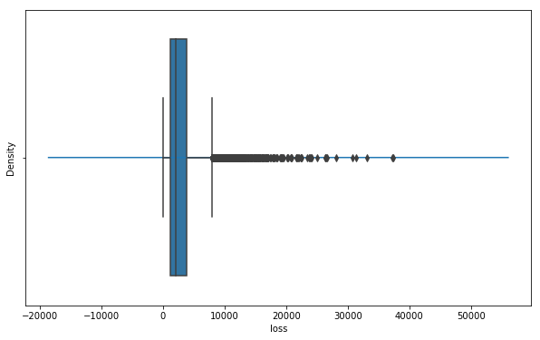

```python
plt.figure(figsize = (10,6))
train["loss"].plot(kind = "kde")
sns.boxplot(train["loss"])
```

As we can see, it seems there are many outliers in the dataset. They may come from catastrophe loss or significant individual loss, but we have no other information to help us figure it out. So we will just keep them in the future analysis.

```python
quantile_value = pd.DataFrame([train["loss"].quantile([0.999, 0.995, 0.99, 0.975, 0.95, 0.9, 0.75, 0.5])]).T
quantile_value.columns = ["Quantile Value in Loss"]
quantile_value.T
```

|  | 0.999 | 0.995 | 0.99 | 0.975 | 0.95 | 0.9 | 0.75 | 0.5 |
| --- | --- | --- | --- | --- | --- | --- | --- | --- |
| Quantile Value in Loss | 25093.7815 | 16976.7659 | 14409.9692 | 10967.3892 | 8542.9115 | 6378.815 | 3884.68 | 2115.51 |

```python
percentile = 0.99
q = train["loss"].quantile(percentile)
loading_percen = train[train["loss"] >= q]["loss"].sum() / train["loss"].sum()
print("Catastrophe Risk Load for", percentile,"percentile:", "{:.3f}".format(loading_percen))

# train = train[train["loss"] < q]
```

```
Catastrophe Risk Load for 0.99 percentile: 0.062
```

```python
reinsur_limit = 13500
loading_limit = train[train["loss"] >= reinsur_limit]["loss"].sum() / train["loss"].sum()
print("Catastrophe Risk Load for", reinsur_limit,"reinsurance limit:", "{:.3f}".format(loading_limit))

# train = train[train["loss"] < reinsur_limit]
```

```
Catastrophe Risk Load for 13500 reinsurance limit: 0.072
```

#### Resolving skewness of the target features

```
Mean: 3046.399249999997
Skewness: 3.01722765391
Kurtosis: 15.7203877478
```

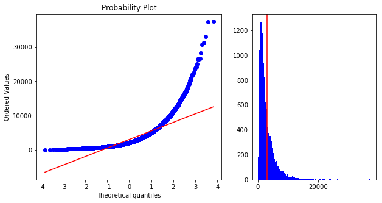

```python
print("Mean:", train["loss"].mean())
print("Skewness:", train["loss"].skew())
print("Kurtosis:", train["loss"].kurtosis())

plt.figure(figsize=(10,5))
gs = gridspec.GridSpec(1,2, width_ratios=(3,2))

ax = plt.subplot(gs[0])
stats.probplot(train["loss"], dist = stats.norm, plot = ax)

ax = plt.subplot(gs[1])
plt.xticks(np.arange(0, max(train["loss"])+1, 20000))
plt.hist(train["loss"], bins=100, color='b')
plt.axvline(train["loss"].mean(), color='r')
```

The skewness is high! Replacing the data with log, square root, or inverse may help to remove the skew. We will deal it with log in this notebook.

```python
train["loss"] = np.log(train["loss"])
```

```
Mean: 7.684807478303276
Skewness: 0.121764329071
Kurtosis: -0.250530459471
```

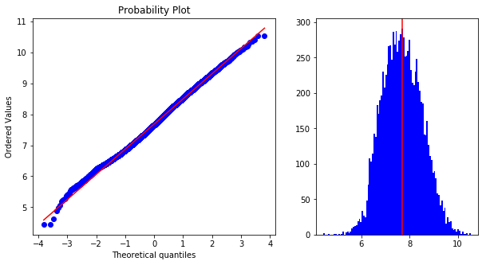

```python
print("Mean:", train["loss"].mean())
print("Skewness:", train["loss"].skew())
print("Kurtosis:", train["loss"].kurtosis())

plt.figure(figsize=(10,5))
gs = gridspec.GridSpec(1,2, width_ratios=(3,2))

ax = plt.subplot(gs[0])
stats.probplot(train["loss"], dist = stats.norm, plot = ax)

ax = plt.subplot(gs[1])
plt.hist(train["loss"], bins=100, color='b')
plt.axvline(train["loss"].mean(), color='r')
```

Now it sounds better!

```python
cont_features.remove("loss")
```

#### Resolving skewness of the continuous features other than target feature

```python
test['loss'] = 0
train_size = len(train)

combined = pd.concat((train, test)).reset_index(drop=True)
combined.drop('id',axis=1,inplace=True)

del train
del test
```

```python
print("Number of missing values in the combined data:",  combined.isnull().sum().sum())
print("-"*20)
print("Shape of combined data:", combined.shape)
```

```
Number of missing values in the combined data: 0
--------------------
Shape of combined data: (16000, 131)
```

```python
skewness = pd.DataFrame(combined[cont_features].apply(lambda x: skew(x.dropna())))
skewness.columns = ["skewness"]
skewness.T
```

|  | cont1 | cont2 | cont3 | cont4 | cont5 | cont6 | cont7 | cont8 | cont9 | cont10 | cont11 | cont12 | cont13 | cont14 |
| --- | --- | --- | --- | --- | --- | --- | --- | --- | --- | --- | --- | --- | --- | --- |
| skewness | 0.526 | -0.3136 | -0.0222 | 0.3937 | 0.6949 | 0.4652 | 0.8245 | 0.6565 | 1.0723 | 0.3649 | 0.2793 | 0.2909 | 0.3953 | 0.24 |

Finding the right transformation to resolve Skewness can be tedious. Box and Cox in their 1964 paper proposed a statistical method to find the right transformation. They suggested using below family of transformations and finding the λ:

[Box-Cox transform](http://shahramabyari.com/2015/12/21/data-preparation-for-predictive-modeling-resolving-skewness/) is defined to be x↦(x^λ−1)/λ, as λ→0 this becomes log(x).

```python
for features in cont_features:
    combined[features] = combined[features] + 1
    combined[features], _ = boxcox(combined[features])
```

```python
skewness = pd.DataFrame(combined[cont_features].apply(lambda x: skew(x.dropna())))
skewness.columns = ["skewness"]
skewness.T
```

|  | cont1 | cont2 | cont3 | cont4 | cont5 | cont6 | cont7 | cont8 | cont9 | cont10 | cont11 | cont12 | cont13 | cont14 |
| --- | --- | --- | --- | --- | --- | --- | --- | --- | --- | --- | --- | --- | --- | --- |
| skewness | 0.0061 | -0.1013 | -0.0283 | 0.0469 | 0.2144 | 0.0399 | 0.0568 | 0.1211 | -0.0147 | 0.023 | 0.0245 | 0.0262 | 0.0989 | 0.0647 |

```python
cont_features.append("loss")
```

### Categorical features

```python
# number and name of categorical features
cat_features = combined.dtypes[combined.dtypes == "object"].index.tolist()
print("Number of categorical features:", len(cat_features))
print("-"*20)
print(cat_features)
```

```
Number of categorical features: 116
--------------------
['cat1', 'cat2', 'cat3', 'cat4', 'cat5', 'cat6', 'cat7', 'cat8', 'cat9', 'cat10', 'cat11', 'cat12', 'cat13', 'cat14', 'cat15', 'cat16', 'cat17', 'cat18', 'cat19', 'cat20', 'cat21', 'cat22', 'cat23', 'cat24', 'cat25', 'cat26', 'cat27', 'cat28', 'cat29', 'cat30', 'cat31', 'cat32', 'cat33', 'cat34', 'c…
```

```python
# data types in the columns of contiunous feature
combined[cat_features].dtypes.value_counts()
```

```
object    116
dtype: int64
```

```python
# explore the distribution of contiunous features
combined[cat_features].describe()
```

|  | cat1 | cat2 | cat3 | cat4 | cat5 | cat6 | cat7 | cat8 | cat9 | cat10 | ... | cat107 | cat108 | cat109 | cat110 | cat111 | cat112 | cat113 | cat114 | cat115 | cat116 |
| --- | --- | --- | --- | --- | --- | --- | --- | --- | --- | --- | --- | --- | --- | --- | --- | --- | --- | --- | --- | --- | --- |
| count | 16000 | 16000 | 16000 | 16000 | 16000 | 16000 | 16000 | 16000 | 16000 | 16000 | ... | 16000 | 16000 | 16000 | 16000 | 16000 | 16000 | 16000 | 16000 | 16000 | 16000 |
| unique | 2 | 2 | 2 | 2 | 2 | 2 | 2 | 2 | 2 | 2 | ... | 18 | 11 | 60 | 98 | 12 | 51 | 50 | 13 | 19 | 227 |
| top | A | A | A | A | A | A | A | A | A | A | ... | F | B | BI | CS | A | E | BM | A | K | HK |
| freq | 11997 | 9037 | 15119 | 10905 | 10452 | 11216 | 15622 | 15052 | 9583 | 13639 | ... | 3987 | 5633 | 12882 | 2150 | 10905 | 2092 | 2287 | 11216 | 3688 | 1778 |

4 rows × 116 columns

#### Convert categorical string values to numeric values

```python
# Unique categorical values per each category
pd.DataFrame(combined[cat_features].apply(pd.Series.nunique)).T
```

|  | cat1 | cat2 | cat3 | cat4 | cat5 | cat6 | cat7 | cat8 | cat9 | cat10 | ... | cat107 | cat108 | cat109 | cat110 | cat111 | cat112 | cat113 | cat114 | cat115 | cat116 |
| --- | --- | --- | --- | --- | --- | --- | --- | --- | --- | --- | --- | --- | --- | --- | --- | --- | --- | --- | --- | --- | --- |
| 0 | 2 | 2 | 2 | 2 | 2 | 2 | 2 | 2 | 2 | 2 | ... | 18 | 11 | 60 | 98 | 12 | 51 | 50 | 13 | 19 | 227 |

1 rows × 116 columns

Use factorize method to convert categorical string values to numeric values is quit easy. It is useful in multi-nomial regression or a multi-class classification problem, where the data needs to be categorized into more than two categories.

```python
combined[cat_features] = combined[cat_features].apply(lambda x:pd.factorize(x)[0])
combined[cat_features].head()
```

|  | cat1 | cat2 | cat3 | cat4 | cat5 | cat6 | cat7 | cat8 | cat9 | cat10 | ... | cat107 | cat108 | cat109 | cat110 | cat111 | cat112 | cat113 | cat114 | cat115 | cat116 |
| --- | --- | --- | --- | --- | --- | --- | --- | --- | --- | --- | --- | --- | --- | --- | --- | --- | --- | --- | --- | --- | --- |
| 0 | 0 | 0 | 0 | 0 | 0 | 0 | 0 | 0 | 0 | 0 | ... | 0 | 0 | 0 | 0 | 0 | 0 | 0 | 0 | 0 | 0 |
| 1 | 0 | 0 | 0 | 1 | 0 | 0 | 0 | 0 | 0 | 0 | ... | 1 | 1 | 1 | 1 | 1 | 1 | 1 | 1 | 1 | 1 |
| 2 | 0 | 0 | 0 | 0 | 1 | 1 | 0 | 0 | 0 | 0 | ... | 2 | 2 | 1 | 2 | 0 | 2 | 2 | 2 | 2 | 2 |
| 3 | 0 | 1 | 0 | 1 | 1 | 1 | 0 | 0 | 0 | 0 | ... | 3 | 0 | 2 | 2 | 1 | 3 | 3 | 2 | 0 | 3 |
| 4 | 0 | 1 | 0 | 0 | 0 | 1 | 0 | 0 | 1 | 1 | ... | 4 | 0 | 2 | 3 | 0 | 4 | 3 | 2 | 3 | 0 |

5 rows × 116 columns

```python
# data types in the columns of contiunous feature
combined[cat_features].dtypes.value_counts()
```

```
int64    116
dtype: int64
```

Another way to converts an attribute to a numerical vector can be done as follows:

```python
#from sklearn.preprocessing import LabelEncoder

#for cf in cat_features:
#    le = LabelEncoder()
#    le.fit(combined[cf].unique())
#    combined[cf] = le.transform(combined[cf])

#combined[cat_features].head()
```

### Correlations between features

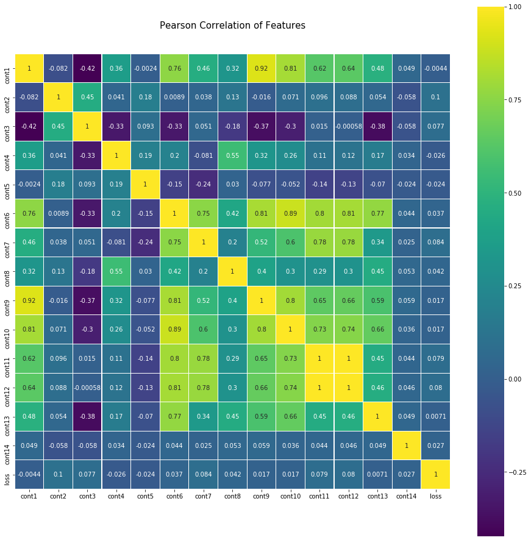

```python
colormap = plt.cm.viridis
plt.figure(figsize=(16,16))
plt.title('Pearson Correlation of Features', y=1.05, size=15)
sns.heatmap(combined.iloc[:train_size][cont_features].corr(method='pearson'),linewidths=0.1,
            vmax=1.0, square=True, cmap=colormap, linecolor='white', annot=True)
```

```python
# Pearson correlation

train_subset = combined.iloc[:train_size]

pd.DataFrame(train_subset.corr(method='pearson')['loss']
                             .abs()).drop('loss').sort_values(['loss'], ascending=[False]).T
```

|  | cat80 | cat12 | cat10 | cat87 | cat101 | cat79 | cat81 | cat1 | cat2 | cat9 | ... | cont13 | cat84 | cat64 | cont1 | cat97 | cat95 | cat83 | cat70 | cat56 | cat86 |
| --- | --- | --- | --- | --- | --- | --- | --- | --- | --- | --- | --- | --- | --- | --- | --- | --- | --- | --- | --- | --- | --- |
| loss | 0.422 | 0.3551 | 0.3109 | 0.3088 | 0.278 | 0.2749 | 0.2738 | 0.2704 | 0.2627 | 0.2432 | ... | 0.0071 | 0.0068 | 0.0065 | 0.0044 | 0.0027 | 0.0021 | 0.0012 | 0.0009 | 0.0006 | 0.0005 |

1 rows × 130 columns

```python
pearson_corr = train_subset.corr(method='pearson').abs()

# the matrix is symmetric so we need to extract upper triangle matrix without diagonal (k = 1)
correlation = (pearson_corr.where(np.triu(np.ones(pearson_corr.shape), k=1)
                              .astype(np.bool)).stack().sort_values(ascending=False))

correlation[correlation > 0.75]
```

```
cont11  cont12    0.9958
cat7    cat89     0.9657
cat2    cat9      0.9330
cont1   cont9     0.9239
cat6    cat50     0.9213
cat8    cat102    0.9074
cat3    cat90     0.9045
cont6   cont10    0.8857
cat86   cat98     0.8516
cat8    cat66     0.8432
cont6   cont9     0.8111
        cont12    0.8107
cat7    cat57     0.8106
cont1   cont10    0.8072
cont6   cont11    0.8037
cat98   cont13    0.8028
cont9   cont10    0.8026
cat3    cat16     0.7991
cat57   cat89     0.7954
cat2    cat101    0.7870
cont7   cont11    0.7824
        cont12    0.7791
cat66   cat102    0.7786
cont6   cont13    0.7679
cat4    cat111    0.7642
cont1   cont6     0.7563
cat5    cat103    0.7552
cont6   cont7     0.7515
dtype: float64
```

```python
# Spearman correlation

from scipy.stats import pointbiserialr, spearmanr

pd.DataFrame(train_subset.corr(method='spearman')['loss'][cat_features]
                                .abs()).sort_values(['loss'], ascending=[False]).T
```

|  | cat80 | cat12 | cat79 | cat87 | cat10 | cat81 | cat101 | cat1 | cat2 | cat9 | ... | cat22 | cat55 | cat95 | cat64 | cat54 | cat98 | cat83 | cat86 | cat70 | cat56 |
| --- | --- | --- | --- | --- | --- | --- | --- | --- | --- | --- | --- | --- | --- | --- | --- | --- | --- | --- | --- | --- | --- |
| loss | 0.4748 | 0.3552 | 0.3507 | 0.3249 | 0.3094 | 0.286 | 0.2829 | 0.2768 | 0.2618 | 0.2423 | ... | 0.0095 | 0.0089 | 0.0087 | 0.0074 | 0.0058 | 0.0034 | 0.0032 | 0.0017 | 0.0016 | 0.0013 |

1 rows × 116 columns

```python
spearman_corr = train_subset.corr(method='spearman').abs()[cat_features]

# the matrix is symmetric so we need to extract upper triangle matrix without diagonal (k = 1)
spearman = (spearman_corr.where(np.triu(np.ones(spearman_corr.shape), k=1)
                                .astype(np.bool)).stack().sort_values(ascending=False))

spearman[spearman > 0.75]
```

```
cat7   cat89     1.0000
cat3   cat90     0.9999
cat8   cat102    0.9995
cat4   cat111    0.9797
cat5   cat103    0.9747
cat2   cat101    0.9487
cat86  cat98     0.9458
cat95  cat99     0.9433
cat2   cat9      0.9330
cat6   cat50     0.9213
cat9   cat101    0.8862
cat66  cat102    0.8436
cat8   cat66     0.8432
cat57  cat89     0.8108
cat7   cat57     0.8106
cat16  cat90     0.7999
cat3   cat16     0.7991
cat91  cat92     0.7914
cat95  cat108    0.7570
dtype: float64
```

Many correlation pairs among categorical features are high. Usually we can use dimensional reduction techniques, like PCA, to select the successive components that explain the maximum variance in the data. Here we will let the machine learning algorithm to learn the pattern of the data.

### Feature reduction

```python
del train_subset

loss = combined["loss"].iloc[:train_size]
combined = combined.drop("loss", 1)

df_train = combined.iloc[:train_size]
df_test = combined.iloc[train_size:]
```

#### 1. Principal component analysis (PCA)

[PCA](http://scikit-learn.org/dev/tutorial/statistical_inference/unsupervised_learning.html#principal-component-analysis-pca) selects the successive components that explain the maximum variance in the signal. The point cloud spanned by the observations is very flat in one direction: one of the three univariate features can almost be exactly computed using the other two. PCA finds the directions in which the data is not flat.

```python
combined_PCA = combined.copy()
```

```python
# check to see if it is suitable to standardize the numerical features before performing PCA
from sklearn.preprocessing import StandardScaler
sc = StandardScaler()
combined_PCA = sc.fit_transform(combined_PCA)
```

```python
# Set n_components to None to keep all principal components and their explained variance
from sklearn.decomposition import PCA
import bisect

start_time = time.time()

threshold = 0.99

pca = PCA(whiten=True)
pca.fit(combined_PCA )

varexp = pca.explained_variance_ratio_.cumsum()
cutoff = bisect.bisect(varexp, threshold)

print(cutoff)
print(pca.explained_variance_ratio_.cumsum()[:cutoff+1])

pca = PCA(n_components=cutoff,whiten=True)
pca = pca.fit(combined_PCA)
data_PCA = pca.transform(combined_PCA)

print("predict time:{}s".format(round((time.time()-start_time), 3) ))
```

```
109
[ 0.06491592  0.1120947   0.15037737  0.18132498  0.21066282  0.2351108
  0.25890528  0.2816763   0.30276248  0.32299007  0.34044278  0.35733917
  0.37243701  0.38661503  0.40025212  0.41250943  0.42426827  0.4358904
  0.44709093  0.45784766  0.46827588  0.47852056  0.48855613  0.49849277
  0.50809282  0.51765383  0.52676133  0.535809    0.54476164  0.55358107
  0.562153    0.57070755  0.57907038  0.58731034  0.59545364  0.60354146
  0.61159246  0.61957762  0.62745172  0.63520459  0.64288845  0.65053079
  0.65809323  0.66552004  0.67293546  0.68028905  0.68759007  0.69483615
  0.70201975  0.70915063  0.71623067  0.72324457  0.73022568  0.73711987
  0.74392874  0.75060879  0.75725134  0.76387485  0.77039956  0.77681605
  0.78320417  0.78953664  0.79583284  0.80209987  0.8082817   0.81440892
  0.82045471  0.82643574  0.83231891  0.83810771  0.84382333  0.84949056
  0.85506088  0.86056773  0.86592536  0.87121048  0.87645488  0.88158321
  0.88666449  0.89148823  0.89618064  0.9007389   0.90525756  0.90965317
  0.91401785  0.91823308  0.92226668  0.92623488  0.93012431  0.93393939
  0.93770794  0.94140294  0.94504099  0.9485966   0.95196594  0.9552798
  0.95849051  0.96163644  0.96466221  0.96760528  0.97053651  0.97334291
  0.97605618  0.97867221  0.98110009  0.9831436   0.98513378  0.98710554
  0.98873778  0.9901176 ]
predict time:0.905s
```

```python
df_train_PCA = data_PCA[:train_size]
df_test_PCA = data_PCA[train_size:]
```

#### 3. t-Distributed Stochastic Neighbor Embedding (t-SNE)

[t-SNE](http://scikit-learn.org/stable/modules/generated/sklearn.manifold.TSNE.html) is a tool to visualize high-dimensional data. It converts similarities between data points to joint probabilities and tries to minimize the Kullback-Leibler divergence between the joint probabilities of the low-dimensional embedding and the high-dimensional data. t-SNE has a cost function that is not convex, i.e. with different initializations we can get different results.

It is highly recommended to use another dimensionality reduction method (e.g. PCA for dense data or TruncatedSVD for sparse data) to reduce the number of dimensions to a reasonable amount (e.g. 50) if the number of features is very high. This will suppress some noise and speed up the computation of pairwise distances between samples.

```python
combined_TSNE = combined.copy()
```

```python
from sklearn.manifold import TSNE

start_time = time.time()

TSNE = TSNE(n_components=2, verbose=2, n_iter=250)
TSNE.fit_transform(combined_TSNE)

print("predict time:{}s".format(round((time.time()-start_time), 3) ))

data_TSNE = combined_TSNE
df_train_TSNE = data_TSNE[:train_size]
df_test_TSNE = data_TSNE[train_size:]
```

[output not shown]

## Model, predict and solve the problem with XGBoost

```python
from IPython.display import Image
Image(filename='datasets/TrvTW.png',width=900, height=900)
```

[output not shown]

### Machine Learning Algorithm Parameters

Algorithm tuning is a final step in the process of applied machine learning before presenting results.

It is sometimes called Hyperparameter optimization where the algorithm parameters are referred to as hyperparameters whereas the coefficients found by the machine learning algorithm itself are referred to as parameters. Optimization suggests the search-nature of the problem.

Phrased as a search problem, you can use different search strategies to find a good and robust parameter or set of parameters for an algorithm on a given problem.

Two simple and easy search strategies are grid search and random search. Scikit-learn provides these [two methods](http://machinelearningmastery.com/how-to-tune-algorithm-parameters-with-scikit-learn/) for algorithm parameter tuning and examples of each are provided below.

The parameters selected are those that maximize the score of the data, unless an explicit score is passed in which case it is used instead.

Here, we will assume the parameters have already been tuned.

```python
import xgboost as xgb

start_time = time.time()

xgb_train = xgb.DMatrix(df_train, loss)
xgb_test = xgb.DMatrix(df_test)

params = {'booster': 'gbtree',
          'objective': 'reg:linear',
          'max_depth': 6,
          'min_child_weight': 4,
          'subsample': 1,
          'colsample_bytree': 0.3,
          'eta': 0.1,
          'seed':0}

model = xgb.train(params, xgb_train , num_boost_round = 1001)
predictions_xgb = np.exp(model.predict(xgb_test))

print("predict time:{}s".format(round((time.time()-start_time), 3) ))
```

```
predict time:12.09s
```

```python
predictions_xgb[:5]
```

```
array([ 2002.16052246,   874.37182617,  1933.02172852,  1393.36865234,
        6631.13330078], dtype=float32)
```